# An Example of Simulating a Trial with Adaptive Enrichment Design

In this vignette, we walk through the simulation of a two-stage adaptive enrichment design with `TrialSimulator`. The idea behind the design is simple. A baseline biomarker splits the patients into a biomarker-positive subgroup and the rest, and we suspect that the treatment works mainly in the subgroup. At an interim analysis, we compute the conditional power for the full population and for the subgroup, and the pair of numbers tells us what to do next: stop for futility, carry on as planned, enroll biomarker-positive patients only from then on (enrichment), or enlarge the trial (promising zone). The two stages are analyzed separately and combined with the inverse normal method, and a closed test with Simes’ test for the intersection hypothesis keeps the family-wise error rate under control across the full-population and subgroup hypotheses.

Most of the building blocks appear in other vignettes. Conditional power and event number reassessment are explained in Conditional power and event number reassessment, and the adaptation functions in Action function. Here we put them together.

## Simulation Settings

- The trial has a placebo arm (`pbo`) and a treatment arm (`trt`), randomized `1:1`.
- A binary baseline `biomarker` is measured at randomization, with a prevalence of 40%. Patients with `biomarker = 1` form the subgroup of interest.
- The only efficacy endpoint is progression-free survival (`PFS`). It is exponential, with a median that depends on the arm and on the biomarker:
  - 6 months in the placebo arm, whatever the biomarker;
  - 6.5 months in biomarker-negative patients of the treatment arm (hazard ratio 0.92);
  - 10 months in biomarker-positive patients of the treatment arm (hazard ratio 0.6).
- Accrual is 6 patients per month for the first 6 months, then 12 patients per month. The planned sample size is 320 patients, and it can grow adaptively.
- Dropout is exponential, with 5% of patients lost by month 12.
- The trial runs in two stages. The first 80 randomized patients form the stage 1 cohort, everybody randomized afterwards belongs to the stage 2 cohort. The two cohorts are analyzed separately and their p-values are combined with the inverse normal method, using the pre-specified weights $w_1 = \sqrt{65/240}$ and $w_2 = \sqrt{175/240}$, i.e., the planned split of the 240 events between the stages. Stage 1 is deliberately small: its job is to inform the interim decision, and most of the information comes from stage 2, after the adaptation.
- As planned, the final analysis takes place when 240 `PFS` events have been observed in the whole trial and the stage 1 cohort has reached 65 events. Keep in mind that this is only the plan; the condition is replaced when the trial is adapted at the interim, as described next.
- The interim decision is made when 45 `PFS` events have been observed in the stage 1 cohort. Let $CP_{full}$ be the conditional power for the full population given the planned 240 events, and $CP_{sub}$ the conditional power for the subgroup given 150 events in the subgroup. Both are computed under the trend observed at the interim, at the one-sided level $\alpha = 0.025$ of the final test. The five decision zones are
  - *futility* if $CP_{full} < 0.01$ and $CP_{sub} < 0.01$: the trial stops at the interim and neither hypothesis is rejected. We picked this cutoff so that, under the alternative described above, about 8% of the trials stop for futility;
  - *unfavorable* if $CP_{full} < 0.2$ and $CP_{sub} < 0.6$ but not in the futility zone: the trial continues as planned;
  - *enrichment* if $CP_{full} < 0.2$ and $CP_{sub} \ge 0.6$: from now on only biomarker-positive patients are enrolled, the accrual rate drops to 5 patients per month because of screening, up to 280 biomarker-positive patients are enrolled in total, and the number of events in the subgroup at the final analysis is re-estimated to reach a conditional power of 0.95, with a cap of 200 events and a floor of 50 events;
  - *promising* if $0.2 \le CP_{full} < 0.9$: the sample size grows to 480 patients and the total number of events at the final analysis is re-estimated to reach a conditional power of 0.95, with a cap of 400 events;
  - *favorable* if $CP_{full} \ge 0.9$: the trial continues as planned.
- The stage 1 analysis takes place when 65 `PFS` events have been observed in the stage 1 cohort. Follow-up of that cohort stops there, which makes the stage 2 data independent of the stage 1 data. We compute one-sided logrank p-values for the full population ($p_{F,1}$) and for the subgroup ($p_{S,1}$), and Simes’ p-value $p_{FS,1} = \min\{2\min(p_{F,1}, p_{S,1}), \max(p_{F,1}, p_{S,1})\}$ for the intersection hypothesis.
- At the final analysis, the same three p-values are computed from the stage 2 cohort. Under enrichment no biomarker-negative patient joins stage 2, so the full-population hypothesis cannot be tested there: its stage 2 p-value is set to 1 and the intersection p-value is just the subgroup p-value.
- Each of the three p-values is combined across the stages with the inverse normal method. The closed test rejects the full-population hypothesis if the combined intersection and full-population p-values are both at most 0.025 (one-sided), and rejects the subgroup hypothesis if the combined intersection and subgroup p-values are both at most 0.025.

## Define Two Arms

Since the distribution of `PFS` depends on the biomarker, we generate the two together with a custom generator. A generator returns a data frame with one column per endpoint. For a time-to-event endpoint, an extra column with the suffix `_event` holds the event indicator. It is always 1 here because the generator produces event times; censoring is handled by `TrialSimulator` at data locks, at adaptations and through dropout. The biomarker is declared with `type = 'baseline'`, a non-time-to-event endpoint observed at randomization, so it needs no readout time.

```r
rng <- function(n, median0, median1, prevalence){
  biomarker <- rbinom(n, size = 1, prob = prevalence)
  pfs <- rexp(n, rate = log(2) / ifelse(biomarker == 1, median1, median0))
  data.frame(biomarker = biomarker, pfs = pfs, pfs_event = 1)
}
```

One call of `endpoint()` gives each arm both of its endpoints. We will meet these generators again at enrichment, when they are swapped for versions that only produce biomarker-positive patients.

```r
pbo_endpoints <- endpoint(name = c('biomarker', 'pfs'),
                          type = c('baseline', 'tte'),
                          generator = rng, median0 = 6, median1 = 6,
                          prevalence = .4)
pbo <- arm(name = 'pbo')
pbo$add_endpoints(pbo_endpoints)

trt_endpoints <- endpoint(name = c('biomarker', 'pfs'),
                          type = c('baseline', 'tte'),
                          generator = rng, median0 = 6.5, median1 = 10,
                          prevalence = .4)
trt <- arm(name = 'trt')
trt$add_endpoints(trt_endpoints)
```

## Define a Trial

The trial starts with 320 planned patients and a piecewise constant accrual rate. Note that there is no end date here: the trial ends when its last milestone is triggered, and the milestones are defined below. We fix a seed so that the single run shown later can be reproduced. In a real simulation study, leave `seed = NULL` and let `TrialSimulator` pick and record a seed for every replicate.

```r
accrual_rate <- data.frame(end_time = c(6, Inf), piecewise_rate = c(6, 12))
trial <- trial(name = 'enrichment', n_patients = 320, seed = 97,
               enroller = StaggeredRecruiter, accrual_rate = accrual_rate,
               dropout = rexp, rate = -log(1 - .05) / 12, ## 5% by month 12
               silent = TRUE)
trial$add_arms(sample_ratio = c(1, 1), pbo, trt)
```

## Define Trial Milestones and Action Functions

The trial has three milestones, named `interim`, `stage 1 analysis` and `final`, and all three are event-driven. The conditions of `interim` and `stage 1 analysis` count events in the stage 1 cohort only, through the subset condition `patient_id <= 80`. Triggering conditions like these, and the way they can be filtered and combined with `&` and `|`, are described in the vignette Condition System for Triggering Milestones in a Trial.

The condition of `final` deserves a closer look. It asks for 240 events in the whole trial, as planned, but also for 65 events in the stage 1 cohort, which is the condition of `stage 1 analysis`. The second part looks redundant, since 65 events in a cohort of 80 patients will normally be reached long before 240 events in the whole trial. It is there for a different reason: `TrialSimulator` triggers milestones in the order in which they are registered, and a milestone whose condition is met before an earlier one raises an error. Repeating the stage 1 condition inside `final` guarantees that `final` can never fire before `stage 1 analysis`, whatever the accrual pattern in a particular replicate. We keep this part in every condition the interim action installs later, for the same reason. The 240 events, on the other hand, are only the plan; the action function of `interim` replaces that part whenever the trial is adapted.

Every milestone comes with an action function, which we write in the following subsections; see the vignette Action function for what an action function can do. The milestone calls below are only displayed at this point; they are run once the action functions exist.

```r
interim <- milestone(name = 'interim', action = interim_action,
                     when = eventNumber(endpoint = 'pfs', n = 45, patient_id <= 80))
stage1 <- milestone(name = 'stage 1 analysis', action = stage1_action,
                    when = eventNumber(endpoint = 'pfs', n = 65, patient_id <= 80))
final <- milestone(name = 'final', action = final_action,
                   when = eventNumber(endpoint = 'pfs', n = 240) &
                     eventNumber(endpoint = 'pfs', n = 65, patient_id <= 80))

listener <- listener(silent = TRUE)
listener$add_milestones(interim, stage1, final)
```

### Interim decision

The action function of `interim` starts by computing the two conditional powers with `trial$conditionalPower()`. The subset condition `patient_id <= 80` restricts the calculation to the stage 1 cohort, and `biomarker == 1` narrows it further to the subgroup. The argument `D` is the number of events we expect at the final analysis, `alpha` is the one-sided level of the final test, and `effect = 'trend'` means the hazard ratio observed at the interim is carried forward.

What happens next depends on the zone. In the futility zone the trial stops. `TrialSimulator` has no dedicated method for stopping a trial early, because a trial simply ends when its last milestone is triggered. So we stop the trial with `trial$update_milestone()`, moving the two remaining milestones to the current calendar time. Both are then triggered right after the interim, enrollment stops there, and their action functions, written below, skip the analyses when they see a futility decision.

In the enrichment zone we make four adaptations:

- `trial$eventNumberReestimationFromConditionalPower()` finds the smallest number of events in the subgroup that reaches the target conditional power, subject to the cap `D_cap`;
- `trial$resize()` raises the maximum sample size so that 280 biomarker-positive patients are enrolled in total;
- `trial$update_accrual_rate()` slows accrual down, because screening for the biomarker takes time;
- `trial$update_generator()` replaces the generators of both arms by the same generator with `prevalence = 1`, so that every patient enrolled from now on is biomarker-positive.

Finally, `trial$update_milestone()` rewrites the triggering condition of the final analysis around the re-estimated number of events in the subgroup. In the promising zone, only the sample size and the total number of events change. Either way, the new condition keeps asking for 65 events in the stage 1 cohort, which guarantees that the stage 1 analysis always comes before the final analysis.

```r
interim_action <- function(trial){

  locked_data <- trial$get_locked_data('interim')

  cp_full <- trial$conditionalPower(
    milestone = 'interim', Surv(pfs, pfs_event) ~ arm, placebo = 'pbo',
    alternative = 'less', alpha = .025, D = 240, effect = 'trend',
    patient_id <= 80)$cp

  cp_sub <- trial$conditionalPower(
    milestone = 'interim', Surv(pfs, pfs_event) ~ arm, placebo = 'pbo',
    alternative = 'less', alpha = .025, D = 150, effect = 'trend',
    patient_id <= 80 & biomarker == 1)$cp

  decision <- if(cp_full < .01 && cp_sub < .01){
    'futility'
  }else if(cp_full < .2 && cp_sub < .6){
    'unfavorable'
  }else if(cp_full < .2){
    'enrichment'
  }else if(cp_full < .9){
    'promising'
  }else{
    'favorable'
  }

  if(decision == 'futility'){

    ## stop the trial now: both remaining milestones are triggered at the
    ## current time, and their action functions skip the analyses
    now <- trial$get_current_time()
    trial$update_milestone(name = 'stage 1 analysis',
                           when = calendarTime(time = now))
    trial$update_milestone(name = 'final',
                           when = calendarTime(time = now))

  }else if(decision == 'enrichment'){

    en <- trial$eventNumberReestimationFromConditionalPower(
      milestone = 'interim', Surv(pfs, pfs_event) ~ arm, placebo = 'pbo',
      alternative = 'less', alpha = .025, target_cp = .95, effect = 'trend',
      patient_id <= 80 & biomarker == 1, D_cap = 200)

    max_events_in_subgroup <- ifelse(en$target_reached, en$D, 200)
    max_patients_in_subgroup <- 280
    enrolled_in_subgroup <- sum(locked_data$biomarker)

    trial$resize(n_patients = nrow(locked_data) +
                   max_patients_in_subgroup - enrolled_in_subgroup)
    trial$update_accrual_rate(
      accrual_rate = data.frame(end_time = Inf, piecewise_rate = 5))

    trial$update_generator(
      arm_name = 'pbo', endpoint_name = c('pfs', 'biomarker'),
      generator = rng, median0 = 6, median1 = 6, prevalence = 1.0)
    trial$update_generator(
      arm_name = 'trt', endpoint_name = c('pfs', 'biomarker'),
      generator = rng, median0 = 6.5, median1 = 10, prevalence = 1.0)

    trial$update_milestone(
      name = 'final',
      when = eventNumber(endpoint = 'pfs', n = max(max_events_in_subgroup, 50),
                         biomarker == 1) &
        eventNumber(endpoint = 'pfs', n = 65, patient_id <= 80))

  }else if(decision == 'promising'){

    en <- trial$eventNumberReestimationFromConditionalPower(
      milestone = 'interim', Surv(pfs, pfs_event) ~ arm, placebo = 'pbo',
      alternative = 'less', alpha = .025, target_cp = .95, effect = 'trend',
      patient_id <= 80, D_cap = 400)

    max_events <- ifelse(en$target_reached, en$D, 400)

    trial$resize(n_patients = 480)
    trial$update_milestone(
      name = 'final',
      when = eventNumber(endpoint = 'pfs', n = max_events) &
        eventNumber(endpoint = 'pfs', n = 65, patient_id <= 80))

  }
  ## 'unfavorable' and 'favorable': no adaptation

  trial$save(value = decision, name = 'decision')
  trial$save(value = cp_full, name = 'cp_full')
  trial$save(value = cp_sub, name = 'cp_subgroup')
}
```

### Stage 1 analysis

The first thing the action function of `stage 1 analysis` does is to call `trial$stop_followup(patient_id <= 80, additional_followup = 0)`, which freezes the stage 1 cohort at the milestone time. From now on these patients look the same in every data lock, and that is exactly what makes the stage 2 p-values independent of the stage 1 p-values. The three stage 1 p-values are then saved with `trial$save()`, ready to be picked up at the final analysis. Note that `fitLogrank()` accepts subset conditions such as `patient_id <= 80` too.

If the trial has already stopped for futility, the action simply returns without saving anything. **There is no need to save `NA` placeholders to keep the output rectangular** — this is a feature of `TrialSimulator` working for you: when the outputs of the replicates are combined, a column that a replicate never saved is filled with `NA` in that replicate’s row automatically. An action function only records what its replicate actually computed, and the summary still sees the same columns in every row.

```r
stage1_action <- function(trial){

  if(trial$get_output('decision') == 'futility'){
    return(invisible(NULL))
  }

  trial$stop_followup(patient_id <= 80, additional_followup = 0)

  locked_data <- trial$get_locked_data('stage 1 analysis')

  pf1 <- fitLogrank(Surv(pfs, pfs_event) ~ arm, placebo = 'pbo',
                    data = locked_data, alternative = 'less',
                    patient_id <= 80)$p
  ps1 <- fitLogrank(Surv(pfs, pfs_event) ~ arm, placebo = 'pbo',
                    data = locked_data, alternative = 'less',
                    patient_id <= 80 & biomarker == 1)$p

  trial$save(value = pf1, name = 'pf1')
  trial$save(value = ps1, name = 'ps1')
  trial$save(value = min(2 * min(pf1, ps1), max(pf1, ps1)), name = 'simes1')
}
```

### Final analysis

At the final analysis, we fetch the values saved earlier in the same replicate with `trial$get_output()`, and compute the stage 2 p-values from the stage 2 cohort only (`patient_id > 80`). After that, the combination and the closed test are a few lines of arithmetic.

Under futility the action again returns early without saving `NA` placeholders for the stage 2 p-values — missing columns are filled with `NA` automatically, as explained at the stage 1 analysis. **The two rejection indicators are a different matter**: a trial stopped for futility rejects nothing, so `FALSE` is their true value, not a placeholder. Saving `FALSE` explicitly is what keeps `mean(reject_full)` in the summary an *unconditional* rejection rate. Had these two columns been left `NA`, the rates would silently have been computed among continuing trials only.

```r
final_action <- function(trial){

  locked_data <- trial$get_locked_data('final')
  decision <- trial$get_output('decision')

  trial$save(value = sum(locked_data$biomarker), name = 'n_positive')

  if(decision == 'futility'){
    trial$save(value = FALSE, name = 'reject_full')
    trial$save(value = FALSE, name = 'reject_subgroup')
    return(invisible(NULL))
  }

  pf1 <- trial$get_output('pf1')
  ps1 <- trial$get_output('ps1')
  simes1 <- trial$get_output('simes1')

  if(decision == 'enrichment'){
    ps2 <- fitLogrank(Surv(pfs, pfs_event) ~ arm, placebo = 'pbo',
                      data = locked_data, alternative = 'less',
                      patient_id > 80 & biomarker == 1)$p
    pf2 <- 1
    simes2 <- ps2
  }else{
    pf2 <- fitLogrank(Surv(pfs, pfs_event) ~ arm, placebo = 'pbo',
                      data = locked_data, alternative = 'less',
                      patient_id > 80)$p
    ps2 <- fitLogrank(Surv(pfs, pfs_event) ~ arm, placebo = 'pbo',
                      data = locked_data, alternative = 'less',
                      patient_id > 80 & biomarker == 1)$p
    simes2 <- min(2 * min(pf2, ps2), max(pf2, ps2))
  }

  trial$save(value = pf2, name = 'pf2')
  trial$save(value = ps2, name = 'ps2')
  trial$save(value = simes2, name = 'simes2')

  w1 <- sqrt(65 / 240)
  w2 <- sqrt(175 / 240)
  combine <- function(p1, p2){
    1 - pnorm(w1 * qnorm(1 - p1) + w2 * qnorm(1 - p2))
  }
  pf <- combine(pf1, pf2)
  ps <- combine(ps1, ps2)
  simes <- combine(simes1, simes2)

  trial$save(value = (simes <= .025 && pf <= .025), name = 'reject_full')
  trial$save(value = (simes <= .025 && ps <= .025), name = 'reject_subgroup')
}
```

Now that the three action functions exist, we run the milestone calls shown at the beginning of this section and register the milestones with a listener.

## Execute a Trial

Let’s run the trial once. With the seed set above, the interim lands in the enrichment zone. The event plot shows the cumulative counts by arm over calendar time, with the three milestones as dashed lines. The `biomarker` panel is really the enrollment curve, since a baseline endpoint is observed as soon as a patient is randomized. It bends at the interim, where accrual slows down to biomarker-positive patients only. In this particular replicate the re-estimated number of subgroup events is reached while enrollment is still going on, so the final analysis fires before the enlarged sample size is used up. That is by design: the final condition is a number of events, and the sample size is only an upper bound.

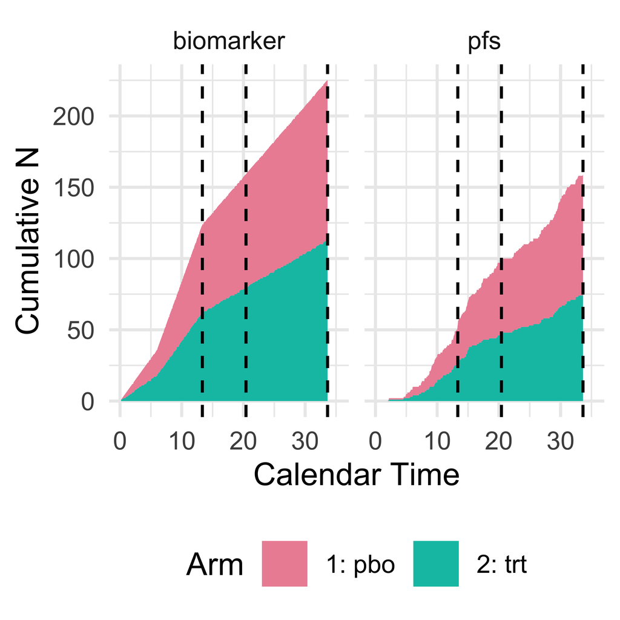

```r
controller <- controller(trial, listener)
controller$run(plot_event = TRUE, silent = TRUE)
```

```r
controller$get_output() %>%
  kable(escape = FALSE) %>%
  kable_styling(bootstrap_options = "striped",
                full_width = FALSE,
                position = "left") %>%
  scroll_box(width = "100%")
```

| trial | seed | milestone_time_<interim> | n_events_<interim>_<pfs> | n_events_<interim>_<biomarker> | n_events_<interim>_<patient_id> | n_events_<interim>_<arms> | decision | cp_full | cp_subgroup | milestone_time_<stage 1 analysis> | n_events_<stage 1 analysis>_<pfs> | n_events_<stage 1 analysis>_<biomarker> | n_events_<stage 1 analysis>_<patient_id> | n_events_<stage 1 analysis>_<arms> | pf1 | ps1 | simes1 | milestone_time_<final> | n_events_<final>_<pfs> | n_events_<final>_<biomarker> | n_events_<final>_<patient_id> | n_events_<final>_<arms> | n_positive | pf2 | ps2 | simes2 | reject_full | reject_subgroup | error_message |
| --- | --- | --- | --- | --- | --- | --- | --- | --- | --- | --- | --- | --- | --- | --- | --- | --- | --- | --- | --- | --- | --- | --- | --- | --- | --- | --- | --- | --- | --- |
| enrichment | 97 | 13.33963 | 54 | 124 | 124 | c(“pbo”,…. | enrichment | 0.0104861 | 0.9936771 | 20.41128 | 100 | 159 | 159 | c(“pbo”,…. | 0.3237104 | 0.014804 | 0.0296079 | 33.6292 | 159 | 225 | 225 | c(“pbo”,…. | 150 | 1 | 0.0230686 | 0.0230686 | FALSE | TRUE |  |

## Execute Trial Simulation

To study the operating characteristics of the design, we run many replicates. The code below was run with 10000 replicates under the alternative described in the settings, and with another 10000 replicates under the global null, where the median of `PFS` in the treatment arm equals the placebo median of 6 months in both biomarker strata. The results are stored in the package, so the vignette does not have to rerun them.

```r
## reset a controller if $run has been executed before
controller$reset()
controller$run(n = 10000, plot_event = FALSE, silent = TRUE, tidy = TRUE)
output <- controller$get_output()
```

```r
output %>%
  filter(scenario == 'alternative') %>%
  select(-scenario) %>%
  head(5) %>%
  kable(escape = FALSE) %>%
  kable_styling(bootstrap_options = "striped",
                full_width = FALSE,
                position = "left") %>%
  scroll_box(width = "100%")
```

| seed | milestone_time_<interim> | n_events_<interim>_<pfs> | n_events_<interim>_<biomarker> | n_events_<interim>_<patient_id> | decision | cp_full | cp_subgroup | milestone_time_<stage 1 analysis> | n_events_<stage 1 analysis>_<pfs> | n_events_<stage 1 analysis>_<biomarker> | n_events_<stage 1 analysis>_<patient_id> | pf1 | ps1 | simes1 | milestone_time_<final> | n_events_<final>_<pfs> | n_events_<final>_<biomarker> | n_events_<final>_<patient_id> | n_positive | pf2 | ps2 | simes2 | reject_full | reject_subgroup |
| --- | --- | --- | --- | --- | --- | --- | --- | --- | --- | --- | --- | --- | --- | --- | --- | --- | --- | --- | --- | --- | --- | --- | --- | --- |
| 1716968512 | 13.24 | 48 | 122 | 122 | promising | 0.3478 | 0.0086 | 22.90 | 133 | 238 | 238 | 0.25950 | 0.146400 | 0.259500 | 49.61 | 400 | 480 | 480 | 198 | 0.5680000 | 0.0066820 | 0.0133600 | FALSE | TRUE |
| 1151366066 | 14.92 | 67 | 143 | 143 | promising | 0.7659 | 0.9915 | 20.01 | 117 | 204 | 204 | 0.01271 | 0.003335 | 0.006669 | 48.36 | 400 | 480 | 480 | 191 | 0.0001214 | 0.0018620 | 0.0002429 | TRUE | TRUE |
| 473618302 | 15.09 | 57 | 145 | 145 | promising | 0.4032 | 0.0200 | 23.51 | 128 | 246 | 246 | 0.37890 | 0.464100 | 0.464100 | 49.38 | 400 | 480 | 480 | 196 | 0.0000168 | 0.0000095 | 0.0000168 | TRUE | TRUE |
| 1521899696 | 13.80 | 55 | 129 | 129 | favorable | 0.9999 | 1.0000 | 28.75 | 186 | 308 | 308 | 0.04332 | 0.042350 | 0.043320 | 35.38 | 240 | 320 | 320 | 121 | 0.0066500 | 0.0185700 | 0.0133000 | TRUE | TRUE |
| 1786717175 | 12.28 | 48 | 111 | 111 | promising | 0.8714 | 0.9987 | 24.80 | 148 | 261 | 261 | 0.08308 | 0.022370 | 0.044750 | 42.15 | 329 | 469 | 469 | 171 | 0.0545000 | 0.0006147 | 0.0012290 | TRUE | TRUE |

Under the alternative, here is how often each zone is reached, and how the adaptations change the duration and the size of the trial. In the futility zone the trial ends at the interim, which is why the three milestone times coincide there.

```r
output %>%
  filter(scenario == 'alternative') %>%
  group_by(decision) %>%
  summarise(
    zone = n() / 100,
    time_interim = mean(`milestone_time_<interim>`),
    time_stage1 = mean(`milestone_time_<stage 1 analysis>`),
    time_final = mean(`milestone_time_<final>`),
    n_final = mean(`n_events_<final>_<patient_id>`),
    n_positive_final = mean(n_positive),
    events_final = mean(`n_events_<final>_<pfs>`)
  ) %>%
  kable(col.names = c('Zone', 'Zone (%)', 'Interim', 'Stage 1', 'Final',
                      'Patients', 'Positive Patients', 'PFS Events'),
        digits = 1, align = 'r',
        caption = 'Decision Zones, Milestone Times, and Trial Size at the Final Analysis') %>%
  add_header_above(c(' ' = 2, 'Time (Months)' = 3, 'At Final Analysis' = 3)) %>%
  kable_styling(full_width = TRUE)
```

Decision Zones, Milestone Times, and Trial Size at the Final Analysis

| Zone | Zone (%) | Time (Months) Interim | Time (Months) Stage 1 | Time (Months) Final | At Final Analysis Patients | At Final Analysis Positive Patients | At Final Analysis PFS Events |
| --- | --- | --- | --- | --- | --- | --- | --- |
| futility | 7.5 | 14.2 | 14.2 | 14.2 | 134.3 | 53.4 | 56.4 |
| unfavorable | 17.3 | 14.3 | 23.5 | 34.9 | 320.0 | 127.7 | 240.0 |
| enrichment | 14.0 | 14.3 | 23.7 | 43.3 | 279.5 | 197.7 | 206.8 |
| promising | 31.6 | 14.3 | 23.8 | 49.1 | 477.5 | 191.0 | 389.5 |
| favorable | 29.6 | 14.4 | 24.1 | 34.9 | 320.0 | 128.3 | 240.0 |

Power is summarized by zone and overall. The three columns “Full Only”, “Subgroup Only” and “Both” are mutually exclusive outcomes, and “Any”, their sum, is the probability of rejecting at least one of the two hypotheses.

```r
power_table <- function(dat){
  dat %>%
    summarise(
      zone = n() / 100,
      reject_full_only = 100 * mean(reject_full & !reject_subgroup),
      reject_subgroup_only = 100 * mean(!reject_full & reject_subgroup),
      reject_both = 100 * mean(reject_full & reject_subgroup),
      reject_any = 100 * mean(reject_full | reject_subgroup)
    )
}

alt <- output %>% filter(scenario == 'alternative')
bind_rows(
  alt %>% group_by(decision) %>% power_table(),
  alt %>% power_table() %>% mutate(decision = 'overall')
) %>%
  kable(col.names = c('Zone', 'Zone (%)', 'Full Only', 'Subgroup Only',
                      'Both', 'Any'),
        digits = 1, align = 'r',
        caption = 'Power (%) under the Alternative') %>%
  add_header_above(c(' ' = 2, 'Rejected Hypotheses (%)' = 4)) %>%
  kable_styling(full_width = TRUE)
```

Power (%) under the Alternative

| Zone | Zone (%) | Rejected Hypotheses (%) Full Only | Rejected Hypotheses (%) Subgroup Only | Rejected Hypotheses (%) Both | Rejected Hypotheses (%) Any |
| --- | --- | --- | --- | --- | --- |
| futility | 7.5 | 0.0 | 0.0 | 0.0 | 0.0 |
| unfavorable | 17.3 | 3.3 | 15.5 | 24.8 | 43.6 |
| enrichment | 14.0 | 0.0 | 77.8 | 0.0 | 77.8 |
| promising | 31.6 | 2.2 | 13.3 | 70.5 | 86.0 |
| favorable | 29.6 | 4.6 | 11.8 | 60.6 | 77.0 |
| overall | 100.0 | 2.6 | 21.2 | 44.5 | 68.4 |

Under the global null, the probability of rejecting at least one hypothesis is the family-wise error rate. The closed test with the inverse normal combination keeps it at the one-sided level 0.025 in the strong sense, whatever we decide at the interim. The rates within a zone, however, are conditional on the interim decision and are not controlled one by one. They are large in the favorable zone precisely because that zone is reached when the interim data happen to look good. Only the overall rate matters. With 10000 replicates, the Monte Carlo standard error of the overall rate is about 0.16 percentage points.

```r
null <- output %>% filter(scenario == 'null')
bind_rows(
  null %>% group_by(decision) %>% power_table(),
  null %>% power_table() %>% mutate(decision = 'overall')
) %>%
  kable(col.names = c('Zone', 'Zone (%)', 'Full Only', 'Subgroup Only',
                      'Both', 'Any'),
        digits = 1, align = 'r',
        caption = 'Type I Error (%) under the Global Null') %>%
  add_header_above(c(' ' = 2, 'Rejected Hypotheses (%)' = 4)) %>%
  kable_styling(full_width = TRUE)
```

Type I Error (%) under the Global Null

| Zone | Zone (%) | Rejected Hypotheses (%) Full Only | Rejected Hypotheses (%) Subgroup Only | Rejected Hypotheses (%) Both | Rejected Hypotheses (%) Any |
| --- | --- | --- | --- | --- | --- |
| futility | 33.3 | 0.0 | 0.0 | 0.0 | 0.0 |
| unfavorable | 27.8 | 0.4 | 0.5 | 0.3 | 1.2 |
| enrichment | 8.7 | 0.0 | 3.5 | 0.0 | 3.5 |
| promising | 21.0 | 1.1 | 1.3 | 1.3 | 3.7 |
| favorable | 9.2 | 2.4 | 2.2 | 2.8 | 7.4 |
| overall | 100.0 | 0.6 | 0.9 | 0.6 | 2.1 |